# Sympton tracker Analysis

Last updated: 03/02/2022

A notebook which loads cleaned flat files of Zoe's Symptom Tracker database, does some light feature engineering, and then undertakes some applications such as trying to replicate the original logistic regression, and then some predictive work.

```
1. Load libraries and data
2. Feature engineering
3. In-sample GLMs:
    3.1 Stepwise logistic regression
    3.2 Menni et al set ('small set') logistic regression
    3.3 Full-set logistic regression
4. Predict the GLMs OSS with 5 folds
5. IMV
6. Seeds
```

## 1. Load libraries and data

Lets first load in our dependancies:

```python
import os
import pandas as pd
import numpy as np
from sklearn.metrics import roc_auc_score
import matplotlib.pyplot as plt
import statsmodels.discrete.discrete_model as sm
import stepwise_selector
from imv_functions import ll, get_w, minimize_me, get_ew
from preprocess import simple_preprocess
from insample import plot_and_print_OR
from prediction_v2 import predict_oos, print_results, predict_oos_compare
update_string = '2021-03-24'
```

Lets define the path of charlies data which is output from the naive 'convert_rds_to_csv.R' file.

```python
data_path = os.path.join(os.getcwd(), '..', '..', 'data','charlie', 'processed')
out_path = os.path.join(os.getcwd(), '..', '..', 'data', 'charlie', 'results', 'second_version', update_string)
if os.path.isdir(out_path) is False:
    os.mkdir(out_path)
if os.path.isdir(os.path.join(out_path, 'imv')) is False:
    os.mkdir(os.path.join(out_path, 'imv'))
if os.path.isdir(os.path.join(out_path, 'roc_auc')) is False:
    os.mkdir(os.path.join(out_path, 'roc_auc'))
```

Lets load in the full dataset:

```python
df = pd.read_csv(os.path.join(data_path, 'set_full.csv'), index_col=0)
```

What columns are in this dataframe that we can use for prediction?

```python
df.columns
```

[output not shown]

```python
df['Simple_Result'] = np.where(df['has_covid'].str.contains('positive'), 1, 0)
```

How many rows do we have?

```python
print(len(df), len(df[df['Simple_Result']==1]))
```

```
435390 27973
```

Lets make a list of the columns that we'll need to not be N/A

```python
with open(r'support_lists/cols_needed.txt') as f:
    cols_needed = [line.rstrip('\n') for line in f]
cols_needed.append('UPDATED_AT.x')
df = df[cols_needed].dropna()
```

How many rows do we have now?

```python
print(len(df))
```

```
430651
```

## 2. Feature Engineering

Lets collapse this into a feature set that we can actually use for prediction out of sample:

First lets set an optional date threshold:

```python
df = df[df['UPDATED_AT.x']< update_string]
```

How many rows and cases do we have now?

```python
print(len(df), df['Simple_Result'].mean())
```

```
430651 0.06444661686609343
```

```python
df = simple_preprocess(df)
```

How many rows do we have now?

```python
print(len(df))
```

```
427588
```

Lets now turn this into a workable dataframe for everything below, as close as possible with the paper.

```python
with open(r'support_lists/full_feature_set.txt') as f:
    full_feature_set = [line.rstrip('\n') for line in f]

df = df[full_feature_set]
```

How does this relate to Table 1 in Menni et al?

```python
pd.merge(df[df['y']==1].mean().rename('Has Covid'),
         df[df['y']==0].mean().rename('No Covid'),
         how='left', left_index=True, right_index=True)
```

|  | Has Covid | No Covid |
| --- | --- | --- |
| y | 1.000000 | 0.000000 |
| age | 45.414305 | 46.476429 |
| female | 0.671135 | 0.742239 |
| bmi | 26.667744 | 26.317857 |
| asmosia | 0.185302 | 0.048218 |
| cough | 0.317132 | 0.140749 |
| fatigue | 0.106510 | 0.065083 |
| skipped_meals | 0.184721 | 0.103717 |
| shortness_of_breath | 0.002361 | 0.001702 |
| fever | 0.272450 | 0.126424 |
| delirium | 0.092815 | 0.074839 |
| diarrhoea | 0.131648 | 0.141049 |
| hoarse | 0.187119 | 0.116677 |
| chest_pain | 0.200523 | 0.136292 |
| abdominal_pain | 0.134445 | 0.147740 |

## 3. In-sample GLMs:

### 3.1 Stepwise logistic regression

```python
#bfit = stepwise_selector.BestSubsetSelectionOLS(fK=7)
#bfit.fit(df[full_feature_set].drop('y', 1), df['y'])
```

```python
#df[full_feature_set].drop('y', 1).iloc[:,bfit.best_model.model.exog_names[1:]].columns
```

### 3.2 Menni et al set ('small set') logistic regression

prediction_model = -1.32 - (0.01 x age) + (0.44 x sex) + (1.75 x loss of smell) + (0.31 x severe or significant cough) + (0.49 x severe fatigue) + (0.39 x skipped meals)

```python
with open(r'support_lists/small_feature_set.txt') as f:
    small_feature_set = [line.rstrip('\n') for line in f]
```

```
                     5%       95%  Odds Ratio
const          0.072938  0.080638    0.076692
age            0.993813  0.995657    0.994734
female         0.676157  0.713217    0.694440
asmosia        3.499144  3.754559    3.624602
cough          2.370595  2.506194    2.437452
fatigue        1.105180  1.206769    1.154858
skipped_meals  1.415609  1.518360    1.466085
```

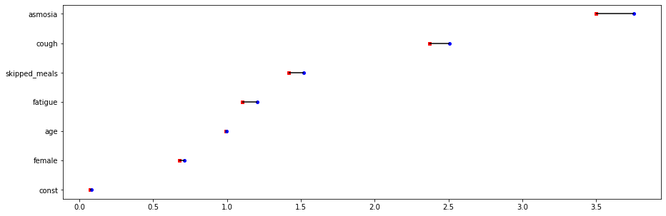

```python
regr = sm.Logit(df['y'], sm.tools.add_constant(df[small_feature_set].drop('y', 1))).fit(disp=0)
regr.summary()
plot_and_print_OR(regr)
```

### 3.3 Full-set logistic regression

```
                           5%       95%  Odds Ratio
const                0.063953  0.074267    0.068917
age                  0.994707  0.996570    0.995638
female               0.676832  0.714249    0.695289
bmi                  0.998779  1.003199    1.000986
asmosia              3.374928  3.626699    3.498550
cough                2.164601  2.295578    2.229128
fatigue              1.054248  1.157052    1.104454
skipped_meals        1.357213  1.460875    1.408090
shortness_of_breath  0.520485  0.890543    0.680819
fever                2.003875  2.131216    2.066565
delirium             0.760695  0.836489    0.797692
diarrhoea            0.743807  0.804718    0.773663
hoarse               1.042806  1.118738    1.080105
chest_pain           1.078662  1.154382    1.115880
abdominal_pain       0.710588  0.769080    0.739256
```

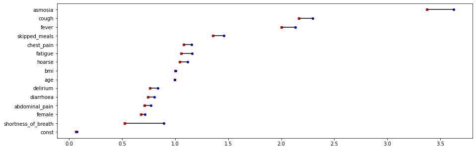

```python
regr = sm.Logit(df['y'], sm.tools.add_constant(df[full_feature_set].drop('y', 1))).fit(disp=0)
regr.summary()
plot_and_print_OR(regr)
```

## 4.1 Predict the GLMs OSS with 5 folds

```python
r2_full, roc_auc_full, imv_full = predict_oos(df[full_feature_set], 5, False, None)
print_results(roc_auc_full, imv_full)
```

```
AUC-ROC mean, min, max, sd: 0.6966729125202921 0.6876658747484096 0.7010299421045731 0.004679297362222556
IMV mean, min, max, sd: 0.006344344940854191 0.005726160126378308 0.007037412565254882 0.00042780190216641043
```

```python
r2_small, roc_auc_small, imv_small = predict_oos(df[small_feature_set], 5, True, None)
print_results(roc_auc_small, imv_small)
```

```
AUC-ROC mean, min, max, sd: 0.6719892300598166 0.667525973831696 0.6791985825958583 0.004356315191277458
IMV mean, min, max, sd: 0.005214195797651002 0.0046981665712132374 0.005903360163217347 0.00038796890267071496
```

## 4.2 Predict the GLMs OSS with 10 folds

```python
r2_small, roc_auc_small, imv_small = predict_oos(df[small_feature_set], 10, False, None, False)
print_results(roc_auc_small, imv_small)
```

```
AUC-ROC mean, min, max, sd: 0.6723735065322991 0.6623807118121394 0.6867176233914091 0.007285064020881441
IMV mean, min, max, sd: 0.005256788078740109 0.0038938538004673643 0.007580324957366573 0.0010643838754154028
```

```python
r2_small, roc_auc_full, imv_full = predict_oos(df[full_feature_set], 10, False, None, False)
print_results(roc_auc_full, imv_full)
```

```
AUC-ROC mean, min, max, sd: 0.6964721857319167 0.6845124674288139 0.7092551564483259 0.007080649157191319
IMV mean, min, max, sd: 0.006375114498781391 0.004517615469809668 0.00887391613050992 0.0013041106238182516
```

## 5. IMV

### 5.1.1 100 stratified draws, small feature set

```python
r2_small, roc_auc_small, imv_small = predict_oos(df[small_feature_set], 100, False, None, True)
file = 'imv_small_firstyear_100folds_noseeds_stratified'
pd.Series(imv_small, name='imv').to_csv(os.path.join(out_path, 'imv', file + '.csv'))
file = 'rocauc_small_firstyear_100folds_noseeds_stratified'
pd.Series(roc_auc_small, name='rocauc').to_csv(os.path.join(out_path, 'roc_auc', file + '.csv'))

file = 'r2_small_firstyear_100folds_noseeds_stratified'
pd.Series(r2_small, name='r2').to_csv(os.path.join(out_path, 'r2', file + '.csv'))


print_results(roc_auc_small, imv_small)
```

```
AUC-ROC mean, min, max, sd: 0.6737815442304279 0.5526249999999999 0.7406571084501602 0.03034313092782985
IMV mean, min, max, sd: 0.0052041196817315845 -0.0007050625395426509 0.01010456929051871 0.0016920020186427145
```

### 5.1.2 100 stratified draws, full feature set

```python
r2_full, roc_auc_full, imv_full = predict_oos(df[full_feature_set], 100, False, None, True)
file = 'imv_full_firstyear_100folds_noseeds_stratified'
pd.Series(imv_full, name='imv').to_csv(os.path.join(out_path, 'imv', file + '.csv'))
file = 'rocauc_full_firstyear_100folds_noseeds_stratified'
pd.Series(roc_auc_full, name='rocauc').to_csv(os.path.join(out_path, 'roc_auc', file + '.csv'))
file = 'r2_full_firstyear_100folds_noseeds_stratified'
pd.Series(r2_full, name='r2').to_csv(os.path.join(out_path, 'r2', file + '.csv'))
print_results(roc_auc_full, imv_full)
```

```
AUC-ROC mean, min, max, sd: 0.6978145648590243 0.5925538949275362 0.7669668946399764 0.02687146639344473
IMV mean, min, max, sd: 0.006314798759050698 0.0006716071428953137 0.012003189077823677 0.0018511092618330813
```

### 5.1.3 100 stratified draws, compared

```python
imv_compare = predict_oos_compare(df[small_feature_set], df[full_feature_set], 100, False, None, True)
file = 'imv_compared_firstyear_100folds_noseeds_stratified'
pd.Series(imv_compare, name='imv').to_csv(os.path.join(out_path, 'imv', file + '.csv'))
print("IMV mean, min, max, sd:", np.mean(imv_compare), np.min(imv_compare), np.max(imv_compare), np.std(imv_compare))
```

```
IMV mean, min, max, sd: 0.0011049011758432104 -0.0005669852448633391 0.002841268159515117 0.0007039642202684518
```

## 6. Seeds

### 6.1.1 10K seeds five folds small feature set (unstratified)

```python
r2_small, roc_auc_small, imv_small = predict_oos(df[small_feature_set], 5, False, [*range(0,10000, 1)], False)
file = 'imv_small_firstwave_5folds_10kseeds_unstratified'
pd.Series(imv_small, name='imv').to_csv(os.path.join(out_path, 'imv', file + '.csv'))
file = 'roc_auc_small_firstwave_5folds_10kseeds_unstratified'
pd.Series(roc_auc_small, name='roc_auc').to_csv(os.path.join(out_path, 'roc_auc', file + '.csv'))

file = 'r2_small_firstwave_5folds_10kseeds_unstratified'
pd.Series(r2_small, name='r2').to_csv(os.path.join(out_path, 'r2', file + '.csv'))

print_results(roc_auc_small, imv_small, 1)
```

```
AUC-ROC mean, min, max, sd: [0.67399249 0.67400887 0.67399594 ... 0.67397389 0.67395393 0.67406661] [0.67238587 0.67028276 0.67224587 ... 0.67085496 0.6674009  0.6703634 ] [0.67591819 0.67543525 0.67837629 ... 0.68063829 0.67974333 0.67903249] [0.00131317 0.00197814 0.00228424 ... 0.00351175 0.00481…
IMV mean, min, max, sd: [0.00522565 0.00522559 0.00522791 ... 0.00522716 0.00522392 0.00522841] [0.00509653 0.00497884 0.00498044 ... 0.00493354 0.00492453 0.00491717] [0.00542475 0.00539317 0.00556331 ... 0.00591418 0.00558397 0.00539903] [0.00012988 0.00015101 0.00020474 ... 0.00037448 0.00025918 …
```

### 6.1.2 10K seeds five folds full feature set (unstratified)

```python
r2_full, roc_auc_full, imv_full = predict_oos(df[full_feature_set], 5, False, [*range(0,10000, 1)], False)
file = 'imv_full_firstwave_5folds_10kseeds_unstratified'
pd.Series(imv_full, name='imv').to_csv(os.path.join(out_path, 'imv', file + '.csv'))
file = 'roc_auc_full_firstwave_5folds_10kseeds_unstratified'
pd.Series(roc_auc_full, name='roc_auc').to_csv(os.path.join(out_path, 'roc_auc', file + '.csv'))

file = 'r2_full_firstwave_5folds_10kseeds_unstratified'
pd.Series(r2_full, name='r2').to_csv(os.path.join(out_path, 'r2', file + '.csv'))

print_results(roc_auc_full, imv_full, 1)
```

```
AUC-ROC mean, min, max, sd: [0.69811035 0.69816305 0.69819653 ... 0.69813825 0.69803335 0.69820487] [0.69647357 0.6943613  0.69403461 ... 0.69488557 0.69235259 0.69313385] [0.70052039 0.70159277 0.70279781 ... 0.70284734 0.70330998 0.70462286] [0.00132359 0.00265664 0.00354791 ... 0.00324281 0.00427…
IMV mean, min, max, sd: [0.00634756 0.00634908 0.00635016 ... 0.00634918 0.006346   0.00635338] [0.00615108 0.00607161 0.00588547 ... 0.00605444 0.00601416 0.00602673] [0.00664602 0.00660242 0.00680673 ... 0.00682808 0.00674841 0.00656303] [0.00016932 0.0001705  0.00030128 ... 0.00031877 0.00028554 …
```

### 6.1.3 10K seeds five folds small feature set (stratified)

```python
r2_small, roc_auc_small, imv_small = predict_oos(df[small_feature_set], 5, False, [*range(0,10000, 1)], True)
file = 'imv_small_firstwave_5folds_10kseeds_stratified'
pd.Series(imv_small, name='imv').to_csv(os.path.join(out_path, 'imv', file + '.csv'))
file = 'roc_auc_small_firstwave_5folds_10kseeds_stratified'
pd.Series(roc_auc_small, name='roc_auc').to_csv(os.path.join(out_path, 'roc_auc', file + '.csv'))

file = 'r2_small_firstwave_5folds_10kseeds_stratified'
pd.Series(r2_small, name='r2').to_csv(os.path.join(out_path, 'r2', file + '.csv'))

print_results(roc_auc_small, imv_small, 1)
```

```
AUC-ROC mean, min, max, sd: [0.67400168 0.67402751 0.67400665 ... 0.67402234 0.67399825 0.67398684] [0.66970932 0.66899968 0.66866634 ... 0.6670519  0.66907569 0.66823754] [0.67761354 0.68261902 0.6778186  ... 0.68194856 0.6760844  0.67813104] [0.00257752 0.00459831 0.00322508 ... 0.00493576 0.00258…
IMV mean, min, max, sd: [0.00522781 0.00522653 0.00522393 ... 0.00522615 0.00522379 0.00522826] [0.0050066  0.00499818 0.00482276 ... 0.00494817 0.00496814 0.00506509] [0.00546731 0.00564649 0.00545339 ... 0.00563246 0.00538769 0.0053675 ] [0.00017755 0.00022689 0.00022985 ... 0.00022725 0.00014229 …
```

### 6.1.4 10K seeds five folds full feature set (stratified)

```python
r2_full, roc_auc_full, imv_full = predict_oos(df[full_feature_set], 5, False, [*range(0,10000, 1)], True)
file = 'imv_full_firstwave_5folds_10kseeds_stratified'
pd.Series(imv_full, name='imv').to_csv(os.path.join(out_path, 'imv', file + '.csv'))
file = 'roc_auc_full_firstwave_5folds_10kseeds_stratified'
pd.Series(roc_auc_full, name='roc_auc').to_csv(os.path.join(out_path, 'roc_auc', file + '.csv'))

file = 'r2_full_firstwave_5folds_10kseeds_stratified'
pd.Series(r2_full, name='r2').to_csv(os.path.join(out_path, 'r2', file + '.csv'))

print_results(roc_auc_full, imv_full, 1)
```

```
AUC-ROC mean, min, max, sd: [0.69818823 0.69806677 0.69804992 ... 0.69812508 0.69809224 0.69814928] [0.69439289 0.69460322 0.69474609 ... 0.69216901 0.69099445 0.69375396] [0.7012704  0.70316981 0.70233383 ... 0.70658928 0.70123494 0.70280817] [0.0023017  0.00308821 0.00279498 ... 0.00541738 0.00371…
IMV mean, min, max, sd: [0.00635379 0.00634683 0.00634626 ... 0.0063442  0.00634697 0.00634588] [0.00614197 0.00615834 0.00590707 ... 0.00597732 0.00602285 0.00612083] [0.00650863 0.00659194 0.00658456 ... 0.00696289 0.00655217 0.00657609] [0.00014539 0.00016935 0.0002486  ... 0.0003344  0.00019335 …
```

### 6.2.1 10K seeds ten folds small feature set (unstratified)

```python
r2_small, roc_auc_small, imv_small = predict_oos(df[small_feature_set], 10, False, [*range(0,10000, 1)], False)
file = 'imv_small_firstwave_10folds_10kseeds_unstratified'
pd.Series(imv_small, name='imv').to_csv(os.path.join(out_path, 'imv', file + '.csv'))
file = 'roc_auc_small_firstwave_10folds_10kseeds_unstratified'
pd.Series(roc_auc_small, name='roc_auc').to_csv(os.path.join(out_path, 'roc_auc', file + '.csv'))

file = 'r2_small_firstwave_10folds_10kseeds_unstratified'
pd.Series(r2_small, name='r2').to_csv(os.path.join(out_path, 'r2', file + '.csv'))


print_results(roc_auc_small, imv_small, 1)
```

```
AUC-ROC mean, min, max, sd: [0.67404646 0.67403427 0.67401468 ... 0.67398512 0.67397706 0.67404859] [0.66799895 0.66817536 0.66986841 ... 0.66743302 0.6636069  0.66240563] [0.68172823 0.68224785 0.67850357 ... 0.68081382 0.68503728 0.68173563] [0.00410575 0.00414913 0.00320107 ... 0.00453591 0.00585…
IMV mean, min, max, sd: [0.00522809 0.005225   0.00522812 ... 0.00522828 0.00522748 0.00522768] [0.00467931 0.00473878 0.00481562 ... 0.00454697 0.00474669 0.00413222] [0.00598394 0.00591597 0.00559283 ... 0.00593025 0.00604568 0.00569971] [0.00037349 0.00032715 0.00027166 ... 0.00046073 0.00034622 …
```

### 6.2.2 10K seeds ten folds tenl feature set (unstratified)

```python
r2_full, roc_auc_full, imv_full = predict_oos(df[full_feature_set], 10, False, [*range(0,10000, 1)], False)
file = 'imv_full_firstwave_10folds_10kseeds_unstratified'
pd.Series(imv_full, name='imv').to_csv(os.path.join(out_path, 'imv', file + '.csv'))
file = 'roc_auc_full_firstwave_10folds_10kseeds_unstratified'
pd.Series(roc_auc_full, name='roc_auc').to_csv(os.path.join(out_path, 'roc_auc', file + '.csv'))

file = 'r2_full_firstwave_10folds_10kseeds_unstratified'
pd.Series(r2_full, name='r2').to_csv(os.path.join(out_path, 'r2', file + '.csv'))


print_results(roc_auc_full, imv_full, 1)
```

[output not shown]

### 6.2.3 10K seeds ten folds small feature set (stratified)

```python
r2_small, roc_auc_small, imv_small = predict_oos(df[small_feature_set], 10, False, [*range(0,10000, 1)], True)
file = 'imv_small_firstwave_10folds_10kseeds_stratified'
pd.Series(imv_small, name='imv').to_csv(os.path.join(out_path, 'imv', file + '.csv'))
file = 'roc_auc_small_firstwave_10folds_10kseeds_stratified'
pd.Series(roc_auc_small, name='roc_auc').to_csv(os.path.join(out_path, 'roc_auc', file + '.csv'))
file = 'r2_small_firstwave_10folds_10kseeds_stratified'
pd.Series(r2_small, name='r2').to_csv(os.path.join(out_path, 'r2', file + '.csv'))
print_results(roc_auc_small, imv_small, 1)
```

```
AUC-ROC mean, min, max, sd: [0.67403959 0.67401378 0.67399753 ... 0.67403485 0.67401436 0.67403919] [0.66803002 0.66238673 0.66156027 ... 0.66181883 0.66457693 0.66324529] [0.6822404  0.68278418 0.68250418 ... 0.68945725 0.68776834 0.68387514] [0.00437964 0.0064379  0.00515778 ... 0.00667928 0.00632…
IMV mean, min, max, sd: [0.00522757 0.00522709 0.00522467 ... 0.0052268  0.00522468 0.00522695] [0.00480662 0.00480514 0.00449377 ... 0.00468822 0.00470636 0.00466166] [0.00559027 0.00577    0.00569522 ... 0.00608678 0.00576587 0.0056854 ] [0.00025096 0.00030262 0.00030242 ... 0.00033867 0.00033833 …
```

### 6.2.4 10K seeds ten folds ten feature set (stratified)

```python
r2_full, roc_auc_full, imv_full = predict_oos(df[full_feature_set], 10, False, [*range(0,10000, 1)], True)
file = 'imv_full_firstwave_10folds_10kseeds_stratified'
pd.Series(imv_full, name='imv').to_csv(os.path.join(out_path, 'imv', file + '.csv'))
file = 'roc_auc_full_firstwave_10folds_10kseeds_stratified'
pd.Series(roc_auc_full, name='roc_auc').to_csv(os.path.join(out_path, 'roc_auc', file + '.csv'))

file = 'r2_full_firstwave_10folds_10kseeds_stratified'
pd.Series(r2_full, name='r2').to_csv(os.path.join(out_path, 'r2', file + '.csv'))

print_results(roc_auc_full, imv_full, 1)
```

```
AUC-ROC mean, min, max, sd: [0.69816475 0.69817501 0.69815859 ... 0.69817211 0.69814027 0.69818868] [0.68903199 0.69078134 0.69009227 ... 0.68721143 0.68761487 0.68869661] [0.70309833 0.70652156 0.70405335 ... 0.71332233 0.70867799 0.70832107] [0.00397286 0.00448213 0.00412261 ... 0.00675924 0.00577…
IMV mean, min, max, sd: [0.00635242 0.00635007 0.00634881 ... 0.00634745 0.00634725 0.00634889] [0.00583699 0.005879   0.00556232 ... 0.00561021 0.00574633 0.00565884] [0.00664794 0.00674507 0.00677424 ... 0.00744052 0.00697183 0.00684121] [0.00024064 0.00027457 0.00032863 ... 0.00044692 0.00039925 …
```